# Introduction to Research Methods

Stijn Masschelein

March, 2018

# Pitching Template

## Convince me and your supervisor of your project’s feasibility

1. Description
   - Title
   - Research Question
   - Key Paper
   - Motivation
2. THREE (IDioT)
   - Idea (+ simulation)
   - Data
   - Tools (+ statistical test)
3. TWO
   - What’s new?
   - So what?
4. ONE contribution
5. Other considerations.

# CEO-firm matching

## New theory

$$V_1(n) - V_0(n) = C V_0(n) T(m)$$

- $n$ is the rank of the size of the firm, $m$ is the rank of the talent of the CEO.
- $n = 1$ is the largest firm, $m = 1$ is the most talented CEO.

## Firm’s decision

$$\max_{m} CV_0(n)T(m) - w(m) \\
m = n\ \land\ w(m) \geq w_0$$

## Three firms - three CEOs model

$$CV_0(1) T(1) - w(1) \geq CV_0(1) T(2) - w(2) \\
CV_0(1) T(1) - w(1) \geq CV_0(1) T(3) - w(3)$$

$$CV_0(2) T(2) - w(2) \geq CV_0(2) T(3) - w(3)$$

## Three firms - three CEOs model

$$CV_0(1) T(1) - w(1) \geq CV_0(1) T(2) - w(2) \\
CV_0(2) T(2) - w(2) \geq CV_0(2) T(3) - w(3)$$

$$CV_0(1) T(1) - w(1) + CV_0(2) T(2) - \color{blue}{w(2)}
\geq CV_0(1) T(2) - \color{blue}{w(2)} + CV_0(2) T(3) - w(3)
\\
CV_0(1) T(1) - w(1) \geq C(V_0(1) - V_0(2))T(2) + C(V_0(2) -
\color{blue}{V_0(1)})T(3) + \color{blue}{CV_0(1)T(3)}- w(3)
\\
CV_0(1) T(1) - w(1) \geq
\color{blue}{C(V_0(1) - V_0(2))(T(2) - T(3))} + CV_0(1)T(3) - w(3)$$

## N firms - N CEOs model

$$CV_0(n) T(n) - w(n) \geq CV_0(n) T(n+1) - w(n+1) \\
w(n) \geq w_0 \\
\forall n = 1,.., N-1$$

$$CV_0(n + 1) (T(n) - T(n+1)) + w(n + 1) = w(n) \\
\forall n = 1,.., N-1$$

> The original papers go further with the derivations. However, this is a recipe we can give to `R` with some further assumptions. So let’s build some fake data in `R`

# Simulating data

## Packages

```r
library(tidyverse)
library(ggplot2)
```

## Simulating $V_0$ and $T$

```r
obs = 500
size_rate = 1; talent_rate = 2/3;
C = 10; scale = 600; w0 = 0;
n = c(1:obs)
size = scale * n ^ (-size_rate)
talent = - 1/talent_rate * n ^ (talent_rate)
```

## Calculating compensation

```r
wage = rep(NA, obs)
wage[obs] = w0
for (i in (obs - 1):1){
  wage[i] = wage[i + 1] + 1/scale * C * size[i + 1] *
    (talent[i] - talent[i + 1])
}
```

## Create a dataset

And put everything in a dataset (or `tibble` in `tidyverse`)

```r
fake_data = tibble(
  n = n,
  size = size,
  talent = talent,
  wage = wage
)
```

## Visualisations

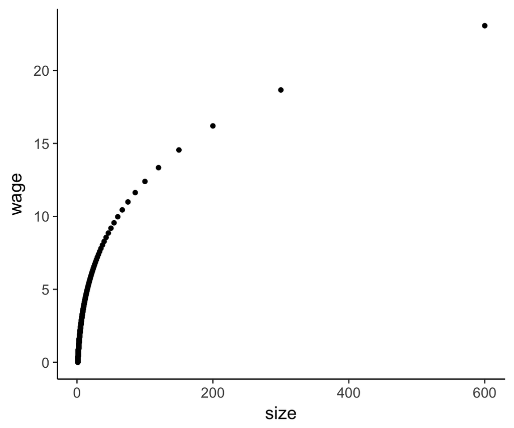

```r
qplot(data = fake_data, x = size, y = wage)
```

## Talent - Size relation

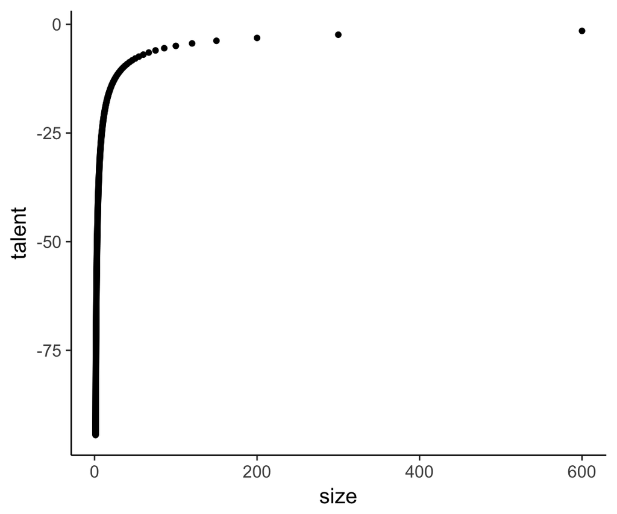

```r
qplot(data = fake_data, y = talent, x = size)
```

## Functions in `R`

```r
create_fake_data = function(obs = 500, size_rate = 1, talent_rate = 1,
                            w0 = .001, C = 1){
  scale = 600
  n = 1:obs
  size = scale * n ^ (-size_rate)
  talent =  -1/talent_rate * n ^ talent_rate
  wage = rep(NA, obs)
  wage[obs] = w0
  for (i in (obs - 1):1){
    wage[i] =  wage[i + 1] + 1/scale * C * size[i + 1] *
      (talent[i] - talent[i + 1])
  }
  fake_data = tibble(n = n, size = size, talent = talent, wage = wage)
  return(fake_data)
}
fake_data = create_fake_data(talent_rate = 2/3, C = 0.01)
```

## Experimenting with your model

```r
data1 = create_fake_data(obs = 500, talent_rate = 2/3, C = .01) %>%
  mutate(talent_rate = "low talent", C = "low effect")
data2 = create_fake_data(obs = 500, talent_rate = 1, C = .01) %>%
  mutate(talent_rate = "high talent", C = "low effect")
data3 = create_fake_data(obs = 500, talent_rate = 2/3, C = .015) %>%
  mutate(talent_rate = "low talent", C = "high effect")
data4 = create_fake_data(obs = 500, talent_rate = 1, C = .015) %>%
  mutate(talent_rate = "high talent", C = "high effect")
data_exp = bind_rows(data1, data2, data3, data4)
data_exp
```

```
## # A tibble: 2,000 x 6
##        n  size talent   wage talent_rate C
##    <int> <dbl>  <dbl>  <dbl> <chr>       <chr>
##  1     1 600    -1.50 0.0241 low talent  low effect
##  2     2 300    -2.38 0.0197 low talent  low effect
##  3     3 200    -3.12 0.0172 low talent  low effect
##  4     4 150    -3.78 0.0156 low talent  low effect
##  5     5 120    -4.39 0.0143 low talent  low effect
##  6     6 100    -4.95 0.0134 low talent  low effect
##  7     7  85.7  -5.49 0.0126 low talent  low effect
##  8     8  75.0  -6.00 0.0120 low talent  low effect
##  9     9  66.7  -6.49 0.0114 low talent  low effect
## 10    10  60.0  -6.96 0.0110 low talent  low effect
## # ... with 1,990 more rows
```

## A more complicated plot with `ggplot`

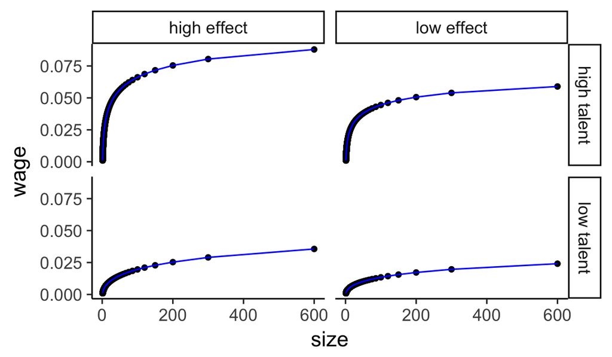

```r
plot_exp = ggplot(data_exp, aes(x = size, y = wage)) +
  geom_point() +
  geom_line(colour = "blue") +
  facet_grid(talent_rate ~ C)
print(plot_exp)
```

## Why simulating data?

- Visualising your theory
- Experimenting and understanding statistical tests
- Experimenting with statistical approaches without peaking at your data.

# Linear regression in `R`

## Notation

$$\mathbf{y} = a + b_1 \mathbf{x_1} + ... + b_n \mathbf{x_n}
+ \mathbf{\epsilon}$$

$$\mathbf{y} = a + \mathbf{b} X + \mathbf{\epsilon}$$

$$\mathbf{y} \sim \mathcal{N}(a + \mathbf{b} X, \sigma)$$

```r
reg = lm(y ~ x1 + x2, data = my_data_set)
summary(reg)
```

## Linear regression with non-linear theories

$$W = aV_0^b \implies ln(W) = log(a) + b\ ln(V_0)$$

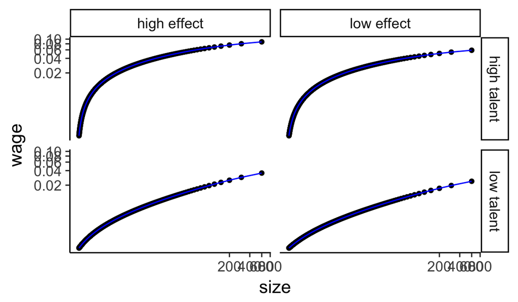

```r
plot_exp +
  scale_x_continuous(trans = "log", breaks = scales::pretty_breaks())  +
  scale_y_continuous(trans = "log", breaks = scales::pretty_breaks())
```

## An example

### But first we need to get the data right.

```r
folder = "~/Dropbox/R/wrds/data/"
us_comp = readRDS(paste0(folder, "us-compensation.RDS")) %>%
  rename(total_comp = tdc1)
us_value = readRDS(paste0(folder, "us-value.RDS")) %>%
  rename(year = fyear, market_value = mkvalt)
summary(us_value$market_value)
```

```
##     Min.  1st Qu.   Median     Mean  3rd Qu.     Max.
##    814.6   8982.7  15599.4  35412.3  32592.8 790050.1
##     NA's
##      777
```

### Some more data wrangling

```r
glimpse(us_value)
```

```
## Observations: 6,710
## Variables: 3
## $ year         <dbl> 2011, 2011, 2012, 2012, 2013, 2013...
## $ gvkey        <chr> "001075", "001075", "001075", "001...
## $ market_value <dbl> 5263.472, 5263.472, 5594.698, 5594...
```

```r
us_value = us_value %>% distinct()
```

### Putting it all together

```r
us_comp_value = left_join(select(us_comp, gvkey, year, total_comp),
                          us_value, by = c("year", "gvkey"))
glimpse(us_comp_value)
```

```
## Observations: 2,981
## Variables: 4
## $ gvkey        <chr> "001045", "001045", "001045", "001...
## $ year         <dbl> 2011, 2012, 2013, 2014, 2015, 2016...
## $ total_comp   <dbl> 5526.835, 656.226, 19092.978, 1230...
## $ market_value <dbl> NA, NA, NA, NA, NA, NA, 5263.472, ...
```

### Finally, the regression

```r
reg = lm(log(total_comp) ~ log(market_value), data = us_comp_value)
# summary(reg)
print(summary(reg), digits = 1L)
```

```
##
## Call:
## lm(formula = log(total_comp) ~ log(market_value), data = us_comp_value)
##
## Residuals:
##    Min     1Q Median     3Q    Max
##  -16.5   -0.2    0.1    0.4    2.8
##
## Coefficients:
##                   Estimate Std. Error t value Pr(>|t|)
## (Intercept)           7.62       0.22      34   <2e-16 ***
## log(market_value)     0.15       0.02       7    5e-11 ***
## ---
## Signif. codes:
## 0 '***' 0.001 '**' 0.01 '*' 0.05 '.' 0.1 ' ' 1
##
## Residual standard error: 1 on 2709 degrees of freedom
##   (270 observations deleted due to missingness)
## Multiple R-squared:  0.02,   Adjusted R-squared:  0.02
## F-statistic: 4e+01 on 1 and 2709 DF,  p-value: 5e-11
```

### Graphical check

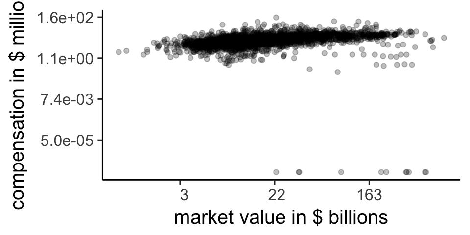

```r
plot_check =
  ggplot(data = us_comp_value, aes(y = total_comp, x = market_value)) +
  geom_point(alpha = .25) +
  scale_x_continuous(trans = "log",
                     labels = function(x)format(x/1000, digits = 2)) +
  scale_y_continuous(trans = "log",
                     labels = function(x)format(x/1000, digits = 2)) +
  ylab("compensation in $ millions") +
  xlab("market value in $ billions")
print(plot_check)
```

```r
plot_check2 = plot_check +
  scale_y_continuous(trans = "log", limits = c(500, NA),
                     labels = function(x)format(x/1000, digits = 2))
```

[output not shown]

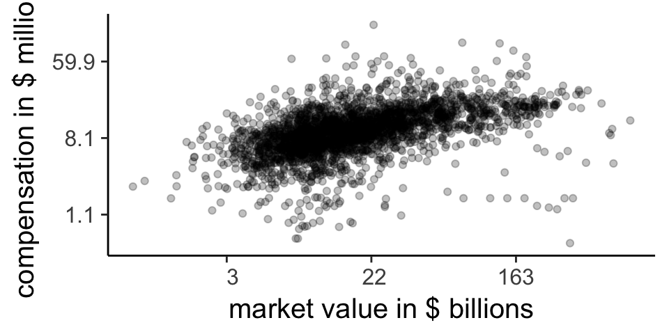

```r
print(plot_check2)
```

# Homework

## Simulations and visualisation

1. Check the conjecture that the log-log transformation makes the theoretical relation between wage-size almost linear for the largest firms.
2. Check whether the compensation-size relation is stable over time.
3. Simulate an exploding time series.
4. Causal structure and control variables